# IMPORTING THE Johnson&Johnson DATA-SET

- The following data-set consist of tweets from the month of 'January' to the month of 'May'based on the keyword [Johnson&Johnson] which has been scrapped from twitter using the library called snscrape
- Our scrapped data consist of the Url, date of the tweet, tweet_content, tweet_id
- For our Analysis we will be only making use of the tweet content inorder to get the sentiment Analysis for the given time duration

```python
import pandas as pd
df= pd.read_csv('/content/drive/MyDrive/Colab Notebooks/Johnson&Johnson_tweets_01-05.csv',low_memory=False)
df
```

|  | Unnamed: 0 | Unnamed: 0.1 | _type | url | date | content | renderedContent | id | user | replyCount | retweetCount | likeCount | quoteCount | conversationId | lang | source | sourceUrl | sourceLabel | outlinks | tcooutlinks | media | retweetedTweet | quotedTweet | inReplyToTweetId | inReplyToUser | mentionedUsers | coordinates | place | hashtags | … |
| --- | --- | --- | --- | --- | --- | --- | --- | --- | --- | --- | --- | --- | --- | --- | --- | --- | --- | --- | --- | --- | --- | --- | --- | --- | --- | --- | --- | --- | --- | --- |
| 0 | 0 | 0 | snscrape.modules.twitter.Tweet | https://twitter.com/ccampo5200/status/13451573... | 2021-01-01 23:57:51+00:00 | @donadolforivas @ClauBSI No.\n\nLa vacuna de J... | @donadolforivas @ClauBSI No.\n\nLa vacuna de J... | 1345157319848558592 | {'_type': 'snscrape.modules.twitter.User', 'us... | 0 | 0 | 1 | 0 | 1345140490497351681 | es | <a href="https://mobile.twitter.com" rel="nofo... | https://mobile.twitter.com | Twitter Web App | NaN | NaN | NaN | NaN | NaN | 1.345140e+18 | {'_type': 'snscrape.modules.twitter.User', 'us... | [{'_type': 'snscrape.modules.twitter.User', 'u... | NaN | NaN | NaN | … |
| 1 | 1 | 1 | snscrape.modules.twitter.Tweet | https://twitter.com/ANGMIRANDA12/status/134515... | 2021-01-01 23:56:10+00:00 | @m_zavala07 @SEDEMA_CDMX Yo compré recientemen... | @m_zavala07 @SEDEMA_CDMX Yo compré recientemen... | 1345156894755704832 | {'_type': 'snscrape.modules.twitter.User', 'us... | 0 | 0 | 2 | 0 | 1345037067613474817 | es | <a href="http://twitter.com/download/android" ... | http://twitter.com/download/android | Twitter for Android | NaN | NaN | NaN | NaN | NaN | 1.345124e+18 | {'_type': 'snscrape.modules.twitter.User', 'us... | [{'_type': 'snscrape.modules.twitter.User', 'u... | NaN | NaN | NaN | … |
| 2 | 2 | 2 | snscrape.modules.twitter.Tweet | https://twitter.com/MesAmisToujours/status/134... | 2021-01-01 23:34:03+00:00 | @lorienttoday Johnson &amp; Johnson &amp; The ... | @lorienttoday Johnson &amp; Johnson &amp; The ... | 1345151331720433667 | {'_type': 'snscrape.modules.twitter.User', 'us... | 0 | 0 | 1 | 0 | 1345077251960922112 | en | <a href="http://twitter.com/download/android" ... | http://twitter.com/download/android | Twitter for Android | NaN | NaN | NaN | NaN | NaN | 1.345077e+18 | {'_type': 'snscrape.modules.twitter.User', 'us... | [{'_type': 'snscrape.modules.twitter.User', 'u... | NaN | NaN | NaN | … |
| 3 | 3 | 3 | snscrape.modules.twitter.Tweet | https://twitter.com/rogrtheshrubber/status/134... | 2021-01-01 23:30:44+00:00 | @Braunger Huey Lewis and the News licensing on... | @Braunger Huey Lewis and the News licensing on... | 1345150493689929728 | {'_type': 'snscrape.modules.twitter.User', 'us... | 0 | 0 | 0 | 0 | 1345144398586159104 | en | <a href="https://mobile.twitter.com" rel="nofo... | https://mobile.twitter.com | Twitter Web App | NaN | NaN | NaN | NaN | NaN | 1.345144e+18 | {'_type': 'snscrape.modules.twitter.User', 'us... | [{'_type': 'snscrape.modules.twitter.User', 'u... | NaN | NaN | NaN | … |
| 4 | 4 | 4 | snscrape.modules.twitter.Tweet | https://twitter.com/RockHound47/status/1345149... | 2021-01-01 23:25:14+00:00 | @AlexBerenson Johnson &amp; Johnson apparently... | @AlexBerenson Johnson &amp; Johnson apparently... | 1345149111981416448 | {'_type': 'snscrape.modules.twitter.User', 'us... | 2 | 0 | 3 | 0 | 1345143619808858113 | en | <a href="http://twitter.com/download/iphone" r... | http://twitter.com/download/iphone | Twitter for iPhone | NaN | NaN | NaN | NaN | NaN | 1.345144e+18 | {'_type': 'snscrape.modules.twitter.User', 'us... | [{'_type': 'snscrape.modules.twitter.User', 'u... | NaN | NaN | NaN | … |
| ... | ... | ... | ... | ... | ... | ... | ... | ... | ... | ... | ... | ... | ... | ... | ... | ... | ... | ... | ... | ... | ... | ... | ... | ... | ... | ... | ... | ... | ... | … |
| 65146 | 12995 | 495 | snscrape.modules.twitter.Tweet | https://twitter.com/arthur_kingsley/status/139... | 2021-05-30 11:51:22+00:00 | We cut off your Johnson &amp; Johnson https://... | We cut off your Johnson &amp; Johnson https://... | 1398970287249526785 | {'_type': 'snscrape.modules.twitter.User', 'us... | 0 | 1 | 0 | 0 | 1398970287249526785 | en | <a href="http://twitter.com/download/android" ... | http://twitter.com/download/android | Twitter for Android | NaN | NaN | [{'_type': 'snscrape.modules.twitter.Gif', 'th... | NaN | NaN | NaN | NaN | NaN | NaN | NaN | NaN | … |
| 65147 | 12996 | 496 | snscrape.modules.twitter.Tweet | https://twitter.com/denver_saw1/status/1398970... | 2021-05-30 11:51:08+00:00 | Científicos alemanes encuentran un mecanismo p... | Científicos alemanes encuentran un mecanismo p... | 1398970228650954752 | {'_type': 'snscrape.modules.twitter.User', 'us... | 0 | 0 | 0 | 0 | 1398970228650954752 | es | <a href="http://twitter.com/download/android" ... | http://twitter.com/download/android | Twitter for Android | ['https://www.businessinsider.es/trombos-astra... | ['https://t.co/Ra91TbkkU7'] | NaN | NaN | NaN | NaN | NaN | NaN | NaN | NaN | NaN | … |
| 65148 | 12997 | 497 | snscrape.modules.twitter.Tweet | https://twitter.com/NathanD43/status/139897003... | 2021-05-30 11:50:22+00:00 | Open SmartNews and read "German scientists say... | Open SmartNews and read "German scientists say... | 1398970033615912962 | {'_type': 'snscrape.modules.twitter.User', 'us... | 0 | 0 | 0 | 0 | 1398970033615912962 | en | <a href="http://twitter.com/download/android" ... | http://twitter.com/download/android | Twitter for Android | ['https://share.smartnews.com/NwFgg', 'https:/... | ['https://t.co/hN2m9WQzL7', 'https://t.co/eaMM... | NaN | NaN | NaN | NaN | NaN | NaN | NaN | NaN | NaN | … |
| 65149 | 12998 | 498 | snscrape.modules.twitter.Tweet | https://twitter.com/GrazynaSzczesna/status/139... | 2021-05-30 11:49:25+00:00 | @kot_phd @KasiaMarkusz To Polacy, którzy mają ... | @kot_phd @KasiaMarkusz To Polacy, którzy mają ... | 1398969795714981896 | {'_type': 'snscrape.modules.twitter.User', 'us... | 2 | 0 | 3 | 0 | 1398882285961859082 | pl | <a href="http://twitter.com/download/android" ... | http://twitter.com/download/android | Twitter for Android | NaN | NaN | NaN | NaN | NaN | 1.398913e+18 | {'_type': 'snscrape.modules.twitter.User', 'us... | [{'_type': 'snscrape.modules.twitter.User', 'u... | NaN | NaN | NaN | … |
| 65150 | 12999 | 499 | snscrape.modules.twitter.Tweet | https://twitter.com/aabolkuuka/status/13989695... | 2021-05-30 11:48:18+00:00 | @Gustaavs @SPKCentrs Pfizer 3 nedēļas starp va... | @Gustaavs @SPKCentrs Pfizer 3 nedēļas starp va... | 1398969515300601856 | {'_type': 'snscrape.modules.twitter.User', 'us... | 1 | 0 | 3 | 0 | 1398968825358524416 | lv | <a href="https://mobile.twitter.com" rel="nofo... | https://mobile.twitter.com | Twitter Web App | NaN | NaN | NaN | NaN | NaN | 1.398969e+18 | {'_type': 'snscrape.modules.twitter.User', 'us... | [{'_type': 'snscrape.modules.twitter.User', 'u... | NaN | NaN | NaN | … |

65151 rows × 30 columns

# The tweet_content which we want to deal with

```python
df = df[df["lang"]== 'en']
```

```python
df['content']
```

```
2        @lorienttoday Johnson &amp; Johnson &amp; The ...
3        @Braunger Huey Lewis and the News licensing on...
4        @AlexBerenson Johnson &amp; Johnson apparently...
7        I wonder which vaccine is hip cool one to get....
11       @snarkyjarky @AZScienceDesk @rociohzz I don't ...
                               ...
65143    “South Korea will get 1m doses of Johnson &amp...
65144    @Sridharmacha @vikramchandra @HiHyderabad @cha...
65145    While you're enjoying the Orlando Farmers Mark...
65146    We cut off your Johnson &amp; Johnson https://...
65148    Open SmartNews and read "German scientists say...
Name: content, Length: 43695, dtype: object
```

# DATA ANALYSIS

```python
!pip install texthero
```

[output not shown]

# We use text Hero Package so that we can get a count of the most recurrent words in the all the scrapped tweets

```python
import numpy as np
import pandas as pd
from copy import deepcopy

import texthero as hero
hero.top_words(df['content'].pipe(hero.clean))
```

```
johnson       77867
amp           41931
co            30324
https         30133
vaccine       27837
              ...
nks1wg3bsd        1
iota              1
1k5ghlskpm        1
3ri1wuar1n        1
xhjxqr21dz        1
Name: content, Length: 75959, dtype: int64
```

## With the help of WordCloud we can visualize the most occuring words in our data-set based on the size of the word (Greater the size of the word greater is its occurance)

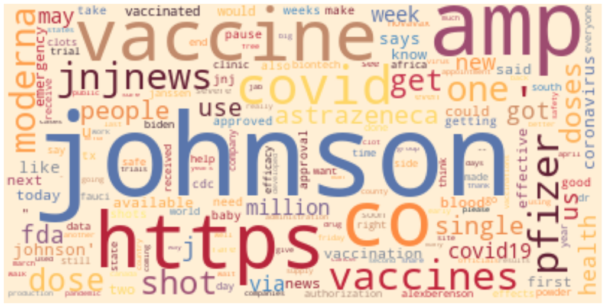

```python
hero.wordcloud(df['content'].pipe(hero.clean))
```

# DATA PREPROCESSING (CLEANING)

```python
!pip install clean-text
```

```
     |████████████████████████████████| 64 kB 1.7 MB/s
     |████████████████████████████████| 174 kB 9.6 MB/s
```

## In this step we are cleaning newline '\n' from the tweets

```python
import html
for i in range (len(df['content'])):

  x = df['content'].replace('\n','') #cleaning newline “\n” from the tweets
df['content'][i] = html.unescape(x)
df['content'].head(10)
```

```
2     @lorienttoday Johnson &amp; Johnson &amp; The ...
3     @Braunger Huey Lewis and the News licensing on...
4     @AlexBerenson Johnson &amp; Johnson apparently...
7     I wonder which vaccine is hip cool one to get....
11    @snarkyjarky @AZScienceDesk @rociohzz I don't ...
12    @DrEricDing ,which one is now the best Covid-1...
13                  @_Durwood @JNJNews Where is my hair
15    @janephilpott @Puglaas Are you competing again...
16    @JNJNews We bought the last two my local Walgr...
17    @ThellyBee I use Aveeno and Aquaphor my son ha...
Name: content, dtype: object
```

# Importing NLTK libraries like stopwards and word_tokenize to perform the following Pre-Processng Tasks

- Lowercasing all your letters
- Removing hashtags, mentions, and links
- Punctuations removal (including filtering non-alphanumeric characters if necessary)
- Tokenization
- Stop words removal

```python
df['content']=df['content'].str.lower()
tweet=df['content'].values.tolist()
```

```python
import pandas as pd
import html
import re
from nltk.corpus import stopwords
from nltk.tokenize import word_tokenize
import nltk

def clean_tweet(tweet):
    if type(tweet) == np.float:
        return ""
    temp = tweet.lower()
    temp = re.sub("'", "", temp) # to avoid removing contractions in english
    temp = re.sub("@[A-Za-z0-9_]+","", temp)
    temp = re.sub("#[A-Za-z0-9_]+","", temp)
    temp = re.sub(r'http\S+', '', temp)
    temp = re.sub('[()!?]', ' ', temp)
    temp = re.sub('\[.*?\]',' ', temp)
    temp = re.sub("[^a-z0-9]"," ", temp)
    temp = temp.split()
    temp = [w for w in temp if not w in stopwords]
    temp = " ".join(word for word in temp)
    return temp
```

```python
from nltk.corpus import stopwords
stopwords = nltk.corpus.stopwords.words('english')
results = [clean_tweet(tw) for tw in tweet]
```

# Stemming the data

```python
import nltk
nltk.download('punkt')
from nltk.stem import PorterStemmer
from nltk.tokenize import sent_tokenize, word_tokenize
words = word_tokenize(str(tweet))
ps = PorterStemmer()
for w in tweet:
	rootWord=ps.stem(w)
	print(rootWord)
```

[output not shown]

[output cut: 88 more lines]

[output not shown]

# Lemmatizing the data

```python
import nltk
nltk.download('omw-1.4')
nltk.download('wordnet')
from nltk.stem import 	WordNetLemmatizer
wordnet_lemmatizer = WordNetLemmatizer()

tokenization = nltk.word_tokenize(str(tweet))
for w in tokenization:

	print("Lemma for {} is {}".format(w, wordnet_lemmatizer.lemmatize(w)))
```

```
Lemma for open is open
Lemma for smartnews is smartnews
Lemma for read is read
Lemma for german is german
Lemma for scientists is scientist
Lemma for say is say
Lemma for figured is figured
Lemma for astrazeneca is astrazeneca
Lemma for johnson is johnson
Lemma for amp is amp
Lemma for johnson is johnson
Lemma for covid is covid
Lemma for 19 is 19
Lemma for vaccines is vaccine
Lemma for cause is cause
Lemma for rare is rare
Lemma for unusual is unusual
Lemma for blood is blood
Lemma for clots is clot
Lemma for read is read
Lemma for web is web
Lemma for tap is tap
```

# IMPORTING TEXTBLOB LIBRARY TO PERFORM SENTIMENT ANALYSIS

```python
from textblob import TextBlob

import tweepy
import sys
```

# In this step we are filtering out all the '@usernames:' and then performing sentiment Analysis based on the Polarity of the tweets

- The tweets which have polarity greater then 0 are classified to be having positive sentiments
- The tweets which have polarity less then 0 are classified t be having negitive sentiments
- The rest of the tweets are considered to be Neutral tweets

```python
polarity = 0
positive = 0
negitive = 0
neutral = 0

for tweet in results :
  final_text = tweet.replace('RT','')
  if final_text.startswith('@'):
    position = final_text.index(':')
    final_text = final_text[position+2:]
  if final_text.startswith('@'):
    position = final_text.index('')
    final_text = final_text[position+2:]
  analysis = TextBlob(final_text)
  tweet_polarity = analysis.polarity
  if tweet_polarity > 0 :
    positive += 1
  elif tweet_polarity< 0 :
    negitive += 1
  else:
    neutral += 1
  polarity += tweet_polarity
print(polarity)
print(f'Amount of positive tweets:{positive}')
print(f'Amount of negitive tweets:{negitive}')
print(f'Amount of neutral tweets:{neutral}')
```

```
3266.3833951263614
Amount of positive tweets:17539
Amount of negitive tweets:7454
Amount of neutral tweets:18702
```

```python
import matplotlib.pyplot as plt
df1 = pd.DataFrame (results, columns = ['cleaned_tweets'])
df1
```

|  | cleaned_tweets |
| --- | --- |
| 0 | johnson amp johnson amp middleton families wor... |
| 1 | huey lewis news licensing one hits johnson amp... |
| 2 | johnson amp johnson apparently traditional dna... |
| 3 | wonder vaccine hip cool one get waiting johnso... |
| 4 | dont disagree pfizer amp moderna great vaccine... |
| ... | ... |
| 43690 | south korea get 1m doses johnson amp johnson v... |
| 43691 | vaccination two phase dosage form vaccines ava... |
| 43692 | youre enjoying orlando farmers market dont for... |
| 43693 | cut johnson amp johnson |
| 43694 | open smartnews read german scientists say figu... |

43695 rows × 1 columns

# Getting the Subjectivity and the Polarity of the tweets

```python
def getSubjectivity(text):
  return TextBlob(text).sentiment.subjectivity

def getPolarity(text):
  return TextBlob(text).sentiment.polarity


df1['Subjectivity']  = df1['cleaned_tweets'].apply(getSubjectivity)
df1['Polarity']  = df1['cleaned_tweets'].apply(getPolarity)
```

```python
df1
```

|  | cleaned_tweets | Subjectivity | Polarity |
| --- | --- | --- | --- |
| 0 | johnson amp johnson amp middleton families wor... | 0.000000 | 0.000000 |
| 1 | huey lewis news licensing one hits johnson amp... | 0.300000 | 0.250000 |
| 2 | johnson amp johnson apparently traditional dna... | 0.775000 | 0.200000 |
| 3 | wonder vaccine hip cool one get waiting johnso... | 0.525000 | -0.025000 |
| 4 | dont disagree pfizer amp moderna great vaccine... | 0.575000 | 0.250000 |
| ... | ... | ... | ... |
| 43690 | south korea get 1m doses johnson amp johnson v... | 0.311111 | 0.022222 |
| 43691 | vaccination two phase dosage form vaccines ava... | 0.450000 | 0.450000 |
| 43692 | youre enjoying orlando farmers market dont for... | 0.700000 | 0.450000 |
| 43693 | cut johnson amp johnson | 0.000000 | 0.000000 |
| 43694 | open smartnews read german scientists say figu... | 0.600000 | 0.125000 |

43695 rows × 3 columns

# Here we can visualize a Word Cloud of the cleaned tweets

```python
from wordcloud import WordCloud
```

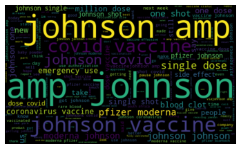

```python
allWords = ''.join([twts for twts in df1['cleaned_tweets']])
wordCloud = WordCloud(width=500,height=300,random_state=21,max_font_size=119).generate(allWords)
plt.imshow(wordCloud,interpolation = 'bilinear')
plt.axis('off')
plt.show()
```

# create a function to compute the negitive neutral and positive analysis and add it as a column in the dataframe

```python
def getAnalysis(score):
  if score < 0:
    return 'Negitive'
  elif score == 0:
    return 'Neutral'
  else:
    return 'Positive'



df1['Sentiments'] = df1['Polarity'].apply(getAnalysis)
df1
```

|  | cleaned_tweets | Subjectivity | Polarity | Sentiments |
| --- | --- | --- | --- | --- |
| 0 | johnson amp johnson amp middleton families wor... | 0.000000 | 0.000000 | Neutral |
| 1 | huey lewis news licensing one hits johnson amp... | 0.300000 | 0.250000 | Positive |
| 2 | johnson amp johnson apparently traditional dna... | 0.775000 | 0.200000 | Positive |
| 3 | wonder vaccine hip cool one get waiting johnso... | 0.525000 | -0.025000 | Negitive |
| 4 | dont disagree pfizer amp moderna great vaccine... | 0.575000 | 0.250000 | Positive |
| ... | ... | ... | ... | ... |
| 43690 | south korea get 1m doses johnson amp johnson v... | 0.311111 | 0.022222 | Positive |
| 43691 | vaccination two phase dosage form vaccines ava... | 0.450000 | 0.450000 | Positive |
| 43692 | youre enjoying orlando farmers market dont for... | 0.700000 | 0.450000 | Positive |
| 43693 | cut johnson amp johnson | 0.000000 | 0.000000 | Neutral |
| 43694 | open smartnews read german scientists say figu... | 0.600000 | 0.125000 | Positive |

43695 rows × 4 columns

# print all the postive tweets

```python
j =1
sortedDF =df1.sort_values(by=['Polarity'])
for i in range (0,sortedDF.shape[0]):
  if(sortedDF['Sentiments'][i]=='Positive'):
    print(str(j) + ')' + sortedDF['cleaned_tweets'][i])
    print()
    j= j+1
```

```
Streaming output truncated to the last 5000 lines.
15040)mit medical think johnson amp johnson vaccine safe short answer yes long answer

15041)killing millions producing threatening variants deadlier amp resistant vaccines right thing suspend patents vaccines increase production help end pandemic

15042)washington c mayor muriel bowser announced residents receive johnson amp johnson single shot covid 19 vaccine get free beer thursday solace brewing co

15043)check week top insights johnson amp johnson vaccine talk therapy

15044)im getting johnson amp johnson shot tomorrow super power one give

15045)two years ago none us thought would possible make pfizer moderna johnson amp johnson vaccine yet literally damn thing freaking proud humanity score 1 good guys

15046)prefer convenience single dose johnson amp johnson vaccine offered straight gate location call 313 230 0505 schedule appointment today full list locations visit

15047)slu hosting johnson amp johnson covid 19 vaccination clinic thursday may 6 11 3 p registration one shot vaccine done prior event walk ins also accepted long doses available register

15048)moderna pfizer johnson amp johnson im sure youve wondering one better best vaccine one person front holding

15049)know longer need make appointment receive covid 19 vaccine fort tuthill vaccination site visit site 8 3 pm receive first second moderna dose site also offering single dose johnson amp johnson vaccine

15050)world calling suspend share science countries produce life saving amp everyone deserves fair shot

15051)dr reimer says age eligibility pending johnson amp johnson doses around 10k confirmed mb based supply province wants offer shot benefit analysis one dose vaccine could helpful homeless

15052)walk ins welcome kaiser reopened stockton arena mass vaccination hub may 7th may 10th johnson amp johnson vaccines appointments walk ins long supplies last

15053)addition offering second dose first pfizer dose patients johnson amp johnson vaccine available adults 18 seek first dose today fillmore veterans memorial building

15054)cmh begin offering johnson amp johnson one dose covid 19 vaccine seaside astoria outpatient pharmacies starting may 10 call primary care clinics schedule appt astoria 503 338 4675 warrenton 503 338 4500 seaside 503 738 3002

15055)oh man really actually got johnson amp johnson im like 80 sure didnt lol one done sore arm pretty sure placebo

15056)new york mets yankees offer vaccinate fans games give free tickets yankees mets offer johnson amp johnson vaccine outside either stadium yankee stadium citi field governor andrew cuomo announced today

15057)covid 19 vaccination update limited number janssen johnson amp johnson appointments still available today legacy events center site farmington want type vaccine please schedule appointment guarantee receive

15058)lucky get spend amount time vermont hike johnson amp johnson covid vaccine via

15059)big news opening homestand huntington park clippers mount carmel providing free johnson amp johnson vaccinations 18 amp older
```

[output cut: 4945 more lines]

```
17532)hypothetical informed person take johnson amp johnson vaccine good ol fashioned viral

17533)example oklahomas attorney general accused johnson amp johnson multi billion dollar brainwashing campaign get doctors overprescribe opioids downplaying addiction risks

17534)appointments available one medical 201 spear johnson amp johnson

17535)german scientists say theyve figured astrazeneca johnson amp johnsons covid 19 vaccines cause rare unusual blood clots

17536)south korea get 1m doses johnson amp johnson vaccine week mainly inoculate military personnel united states almost doubled pledge made earlier month prime minister kim boo kyum said sunday

17537)vaccination two phase dosage form vaccines available except johnson amp johnson take two dose vaccine takes two months time better get vaccinated one month recovery

17538)youre enjoying orlando farmers market dont forget stop get free covid 19 vaccine every sunday end june orlando farmers market e washington st n eola dr 10 6 p johnson amp johnson brand individuals 18

17539)open smartnews read german scientists say figured astrazeneca johnson amp johnson covid 19 vaccines cause rare unusual blood clots read web tap
```